# Holt Winters

Mike

2023-03-21

# Suavizacioón exponencial para datos estacionales: Método de Holt - Winters

Vamos analizar las series de ingresos de comercio al por mayor y al por menor de Jalisco. Estos datos son números ìndices, año base 2013. La fuente de información es INEGI.

## Comercio al por menor

Analizamos primero este sector. Iniciamos de la manera estándar

```r
rm(list=ls())

library(readxl)
library(tidyverse)
library(forecast)
```

```r
setwd("~/Documents/suavizacion")

datos <- read_excel("indices_comercio.xlsx")
names(datos) <- c("anio", "mes", "mayor", "menor")

mayor <- ts(datos$mayor, start = c(2008,1), frequency = 12)
menor <- ts(datos$menor, start = c(2008,1), frequency = 12)
```

Analizamos graficamente la serie de ingreso de comercio al por menor de Jalisco.

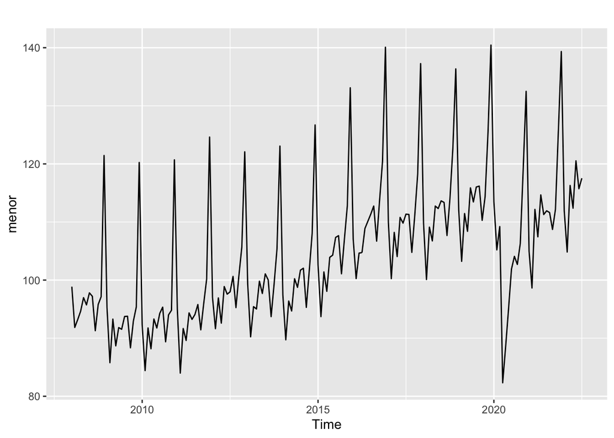

```r
autoplot(menor)
```

Vamos hacer una gráfica estacional, para ello usamos la función *ggsubseriesplot*; junta todos los periodos de todos los años y gráfica la media, y *ggseasonplot* cada linea es un año y cada punto un mes, para identificar estos patrones.

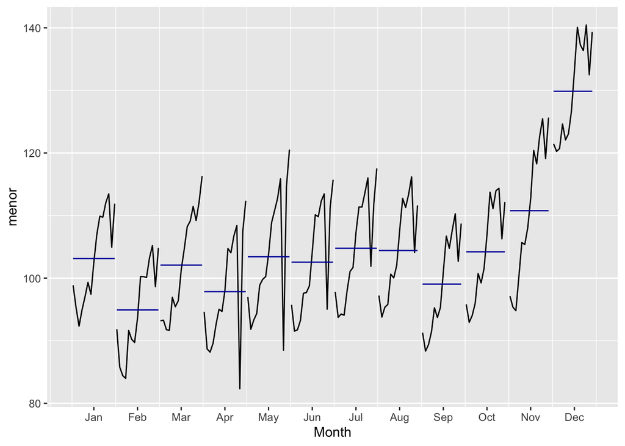

```r
ggsubseriesplot(menor)
```

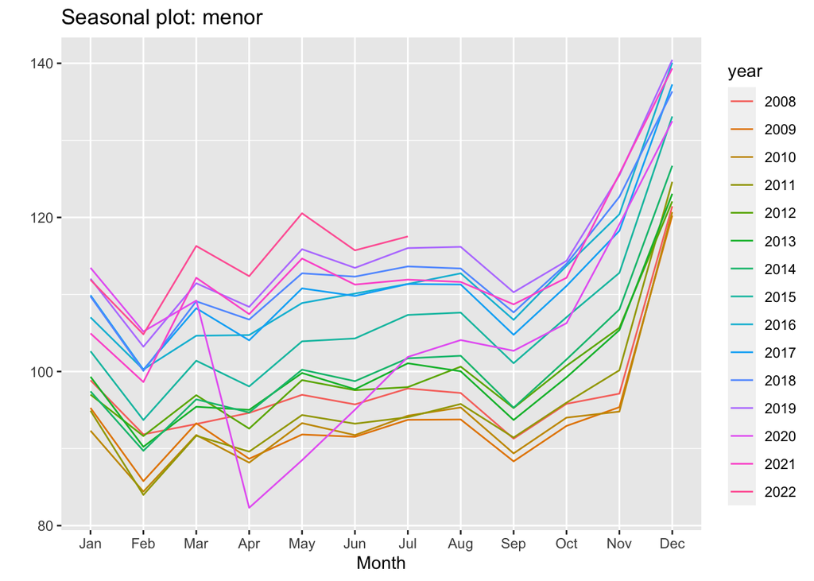

```r
ggseasonplot(menor)
```

Según el comportamiento de esta serie, podemos usar la suavización con estacionalidad aditiva para pronosticar los siguientes 12 meses. Para ello usamos la función *hw*, la cual sirve para estimar el método de Holt-Winters.

Para el método aditivo, usamos la opción *seasonal = “additive”*:

```r
pronostico_menor <- hw(menor, h=12, seasonal = "additive")
```

Para comparar generamos el pronostico con la estacionalidad multiplicativa, para ello usamos la opción *seasonal = “multiplicative”*:

```r
pronostico_menor2 <- hw(menor, h=12, seasonal = "multiplicative")
```

Analizamos los pronósticos:

```r
pronostico_menor
```

```
##          Point Forecast    Lo 80    Hi 80     Lo 95    Hi 95
## Aug 2022       118.4430 114.6046 122.2815 112.57260 124.3134
## Sep 2022       113.0273 108.2596 117.7949 105.73579 120.3187
## Oct 2022       118.2768 112.7334 123.8202 109.79894 126.7547
## Nov 2022       124.8155 118.5922 131.0389 115.29776 134.3333
## Dec 2022       143.9725 137.1364 150.8087 133.51755 154.4276
## Jan 2023       117.1747 109.7761 124.5732 105.85960 128.4898
## Feb 2023       108.9949 101.0736 116.9161  96.88040 121.1093
## Mar 2023       116.1097 107.6981 124.5213 103.24523 128.9742
## Apr 2023       111.7807 102.9057 120.6558  98.20747 125.3540
## May 2023       117.6657 108.3500 126.9813 103.41864 131.9127
## Jun 2023       116.9745 107.2381 126.7109 102.08401 131.8650
## Jul 2023       119.1193 108.9795 129.2591 103.61177 134.6267
```

```r
pronostico_menor2
```

```
##          Point Forecast     Lo 80    Hi 80     Lo 95    Hi 95
## Aug 2022       117.8401 113.23522 122.4449 110.79756 124.8826
## Sep 2022       112.8028 106.93065 118.6749 103.82212 121.7834
## Oct 2022       117.2268 109.70976 124.7439 105.73047 128.7232
## Nov 2022       127.9872 118.28123 137.6931 113.14322 142.8311
## Dec 2022       142.8800 130.38724 155.3728 123.77395 161.9861
## Jan 2023       116.0568 104.56099 127.5526  98.47547 133.6382
## Feb 2023       108.4026  96.39560 120.4096  90.03949 126.7657
## Mar 2023       117.3021 102.91984 131.6844  95.30631 139.2979
## Apr 2023       108.8679  94.21206 123.5237  86.45375 131.2820
## May 2023       116.9175  99.75230 134.0828  90.66557 143.1695
## Jun 2023       116.7180  98.13587 135.3001  88.29910 145.1368
## Jul 2023       119.9586  99.34989 140.5673  88.44031 151.4768
```

Para ver gráficamente los pronósticos:

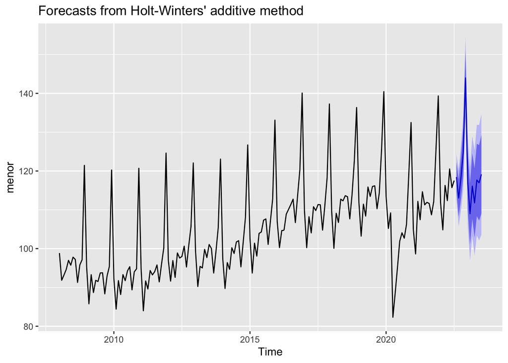

```r
autoplot(pronostico_menor)
```

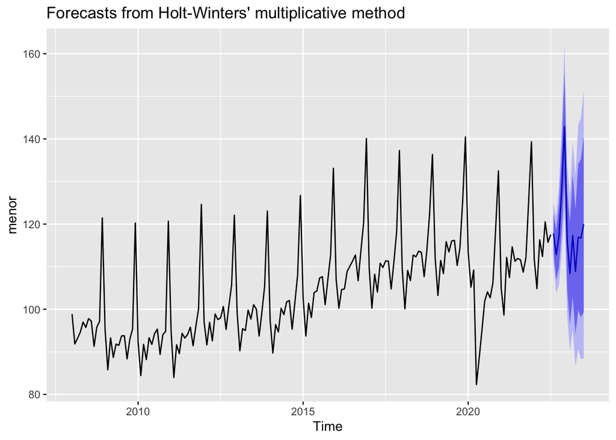

```r
autoplot(pronostico_menor2)
```

Graficamos en una misma figura, PI=FALSE es para ocultar los intervalos de confianza

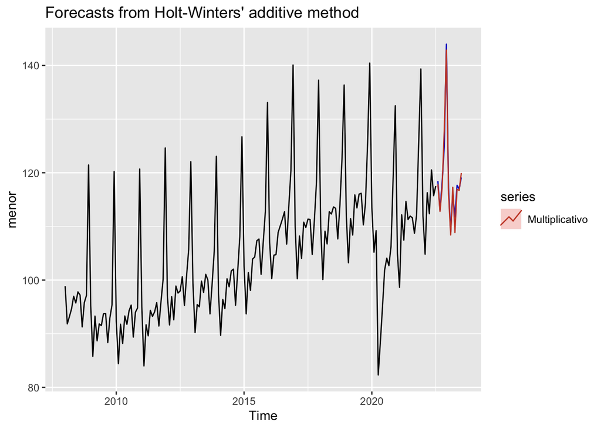

```r
autoplot(pronostico_menor, PI=FALSE, series="Aditivo") +
  autolayer(pronostico_menor2, PI=FALSE, series="Multiplicativo")
```

Podemos exportar estos resultados:

```r
write.csv(pronostico_menor, "pronostico_final.csv")
```

Podemos extraer elementos de la tabla que contiene el pronostico, nos interesa generar un objeto que contengan solo el pronostico puntual:

```r
solo_pronostico <- pronostico_menor$mean

solo_pronostico
```

```
##           Jan      Feb      Mar      Apr      May      Jun      Jul      Aug
## 2022                                                                118.4430
## 2023 117.1747 108.9949 116.1097 111.7807 117.6657 116.9745 119.1193
##           Sep      Oct      Nov      Dec
## 2022 113.0273 118.2768 124.8155 143.9725
## 2023
```

Finalmente analizamos los intervalos de confianza al 95%

```r
pronostico_menor
```

```
##          Point Forecast    Lo 80    Hi 80     Lo 95    Hi 95
## Aug 2022       118.4430 114.6046 122.2815 112.57260 124.3134
## Sep 2022       113.0273 108.2596 117.7949 105.73579 120.3187
## Oct 2022       118.2768 112.7334 123.8202 109.79894 126.7547
## Nov 2022       124.8155 118.5922 131.0389 115.29776 134.3333
## Dec 2022       143.9725 137.1364 150.8087 133.51755 154.4276
## Jan 2023       117.1747 109.7761 124.5732 105.85960 128.4898
## Feb 2023       108.9949 101.0736 116.9161  96.88040 121.1093
## Mar 2023       116.1097 107.6981 124.5213 103.24523 128.9742
## Apr 2023       111.7807 102.9057 120.6558  98.20747 125.3540
## May 2023       117.6657 108.3500 126.9813 103.41864 131.9127
## Jun 2023       116.9745 107.2381 126.7109 102.08401 131.8650
## Jul 2023       119.1193 108.9795 129.2591 103.61177 134.6267
```

# Comercio al por mayor